# Distributions: Discrete and Continuous

## 1.2 Cumulative Distribution Functions

Write a function to plot the cumulative distribution function of the Binomial random variable, call it ‘plot_binom_cdf’.

```r
plot_binom_cdf <- function(n, p) {
  x <- 0:n  # Possible values of the random variable
  cdf <- pbinom(x, size = n, prob = p)  # Calculate the CDF

  # Plot the CDF
  plot(x, cdf, type = "s", lwd = 2, xlab = "X", ylab = "CDF",
       main = paste("Binomial CDF (n =", n, ", p =", p, ")"))
}
```

Fix n = 40. Compute plots of the of the graphs cdf for the following values of p: 0.05, 0.1, 0.4, 0.6, 0.9, 0.95. Have all graphs on the same plot (with different colors). Draw a horizontal line at $y=0.8$.

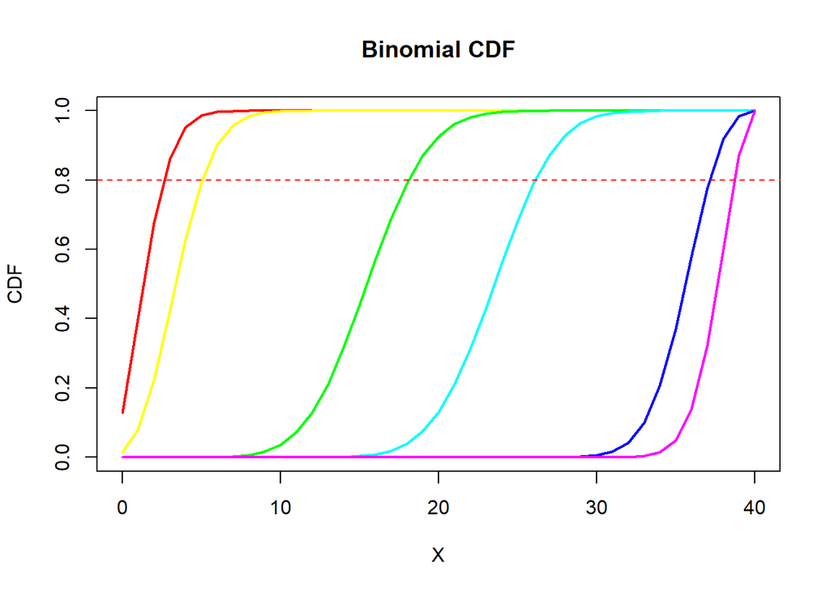

```r
n <- 40
p_values <- c(0.05, 0.1, 0.4, 0.6, 0.9, 0.95)

# Create an empty plot
plot(1, type = "n", xlim = c(0, n), ylim = c(0, 1), xlab = "X", ylab = "CDF", main = "Binomial CDF")

# Loop through the p values and plot the CDFs
colors <- rainbow(length(p_values))
for (i in 1:length(p_values)) {
  p <- p_values[i]
  x <- 0:n
  cdf <- pbinom(x, size = n, prob = p)
  lines(x, cdf, col = colors[i], lwd = 2)
}

# Add a horizontal line at y = 0.8
abline(h = 0.8, col = "red", lty = 2)
```

Interpret the values of $x$ where the line $y=0.8$ intersects the graphs of the different cdf. YOUR ANSWER: - The cdf represents the probability that the random variable is less than or equal to a value x. Based on the red line, we can see the different x values for each plot that have a probability that is less than or equal to .8

# 2 Poisson Distribution.

## 2.1 Probability Mass Functions

We will plot the mass function for the Poison distribution Pois(mu). Note: 1) The values for this random variable are: 0, 1, 2, 3, …. 2) The density plot will have a bar of height P(X=k), at the point ‘k’ on the x-axis. 3) Since most of the densities will be concentrated at lower values of k, we will fix a large enough value of n, say n = 100, when drawing the density plots. 3) In the plot include a vertical line at the expected value of Pois(mu).

Write a function plot_pois, that takes input values: mu, and returns the density plot of Pois(mu).

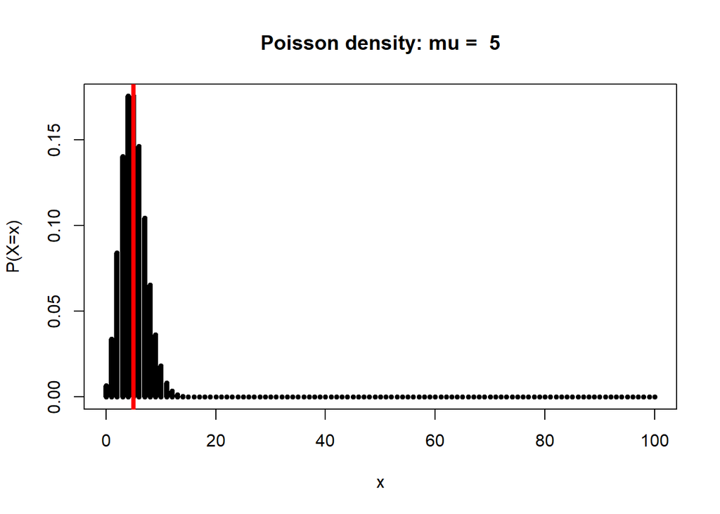

```r
n <- 100
plot_pois_pmf <- function(mu){
  x <- 0:n
  pois <- dpois(x, lambda = mu)
  mu_X <- mu
  plot(x, pois, type = "h", lwd = 5,
       main = paste("Poisson density: mu = ", mu),
       xlab = "x", ylab = "P(X=x)")
  abline(v = mu_X, col = 'red', lwd = 4)
}

plot_pois_pmf(5)
```

For the following values of mu compute the plots for the pmf of the Poisson distribution: mu: 0.5, 1, 5, 8, 20, 50. Have all plots on the same frame.

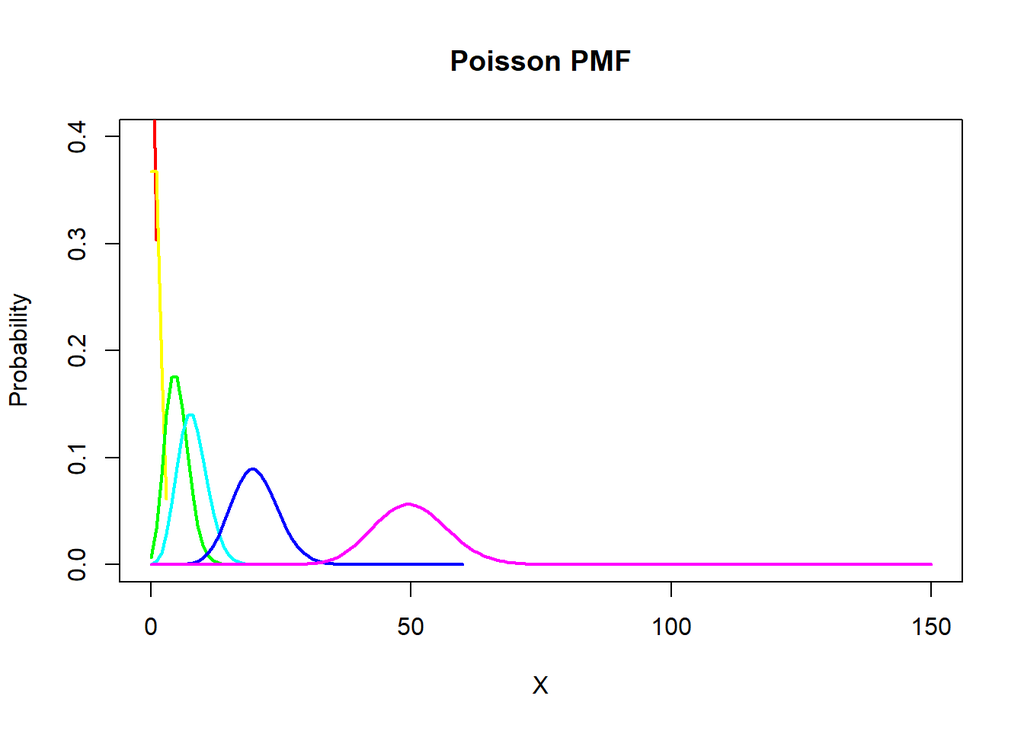

```r
mu_values <- c(0.5, 1, 5, 8, 20, 50)

# Create an empty plot
plot(1, type = "n", xlim = c(0, max(mu_values) * 3), ylim = c(0, 0.4), xlab = "X", ylab = "Probability", main = "Poisson PMF")

# Loop through the mu values and plot the PMFs
colors <- rainbow(length(mu_values))
for (i in 1:length(mu_values)) {
  mu <- mu_values[i]
  x <- 0:(mu * 3)
  pmf <- dpois(x, lambda = mu)
  lines(x, pmf, col = colors[i], lwd = 2)
}
```

## 2.2 Cumulative Distribution Functions

Write a function ‘plot_pois_cdf’ that takes input $\mu$ and returns the plot of the cdf of the $\text{Pois}(\mu)$.

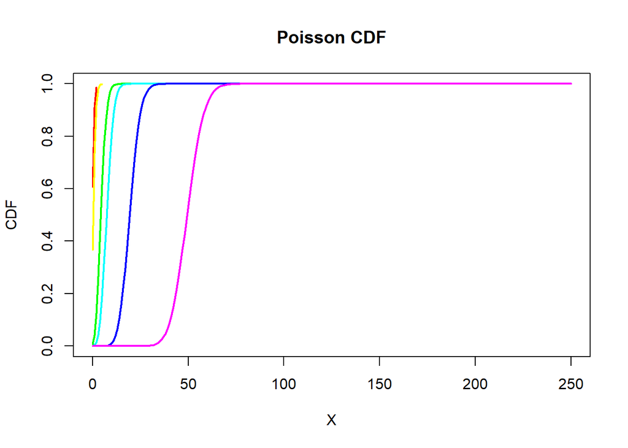

```r
plot_pois_cdf <- function(mu) {
  x <- 0:(mu * 5)  # Adjust the range as needed
  cdf <- ppois(x, lambda = mu)  # Calculate the Poisson CDF
  plot(x, cdf, type = "s", lwd = 2, xlab = "X", ylab = "CDF",
       main = paste("Poisson CDF (mu =", mu, ")"))
}

# Define the values of mu
mu_values <- c(0.5, 1, 5, 8, 20, 50)

# Create an empty plot
plot(1, type = "n", xlim = c(0, max(mu_values) * 5), ylim = c(0, 1), xlab = "X", ylab = "CDF", main = "Poisson CDF")

# Loop through the mu values and plot the CDFs
colors <- rainbow(length(mu_values))
for (i in 1:length(mu_values)) {
  mu <- mu_values[i]
  x <- 0:(mu * 5)
  cdf <- ppois(x, lambda = mu)
  lines(x, cdf, col = colors[i], lwd = 2)
}
```

For the following values of mu compute the plots for the pmf of the Poisson distribution: mu: 0.5, 1, 5, 8, 20, 50. Have all plots on the same frame.

# 3 Comparing Poison with Binomial

We say two random variables $X$ and $Y$ are identically distributed if they have the same cumulative distribution functions, that is
$$F_X(u) = F_Y(u) \quad \quad \forall x\in
\mathbb{R}$$
In class we noted the Poisson approximation of the Binomial distribution. Let’s visualize it now:

Plot the graphs of the cdf of $\text{Binom}(n=10, p=0.5)$ and $\text{Pois}(\mu= 5)$ on the same plot.

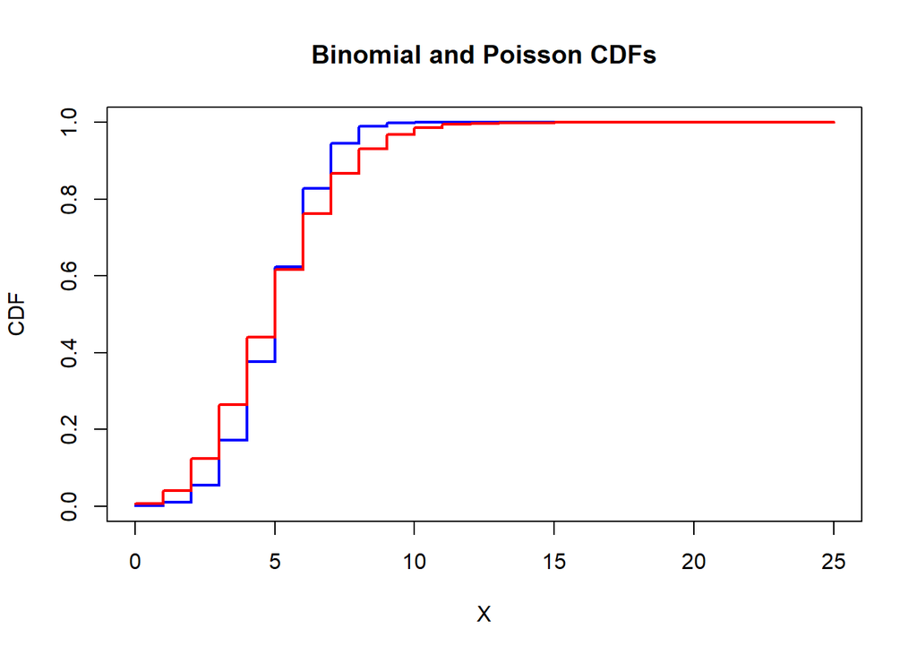

```r
n <- 10
p <- 0.5
mu <- 5

# Create a vector of x values
x <- 0:max(n, mu * 5)

# Calculate CDFs for both distributions
binom_cdf <- pbinom(x, size = n, prob = p)
poisson_cdf <- ppois(x, lambda = mu)

# Create a plot
plot(x, binom_cdf, type = "s", col = "blue", lwd = 2,
     xlab = "X", ylab = "CDF", main = "Binomial and Poisson CDFs")
lines(x, poisson_cdf, type = "s", col = "red", lwd = 2)
```

Do the graphs overlap? Why/Why not? YOUR ANSWER: - The graphs do overlap, as we see some cdf values intersect when x is between 4-7 and when x is between 11 onwards. Now plot the graphs of the cdf of $\text{Binom}(n= 1000, p= 0.005)$ and $\text{Pois}(\mu= 5)$.

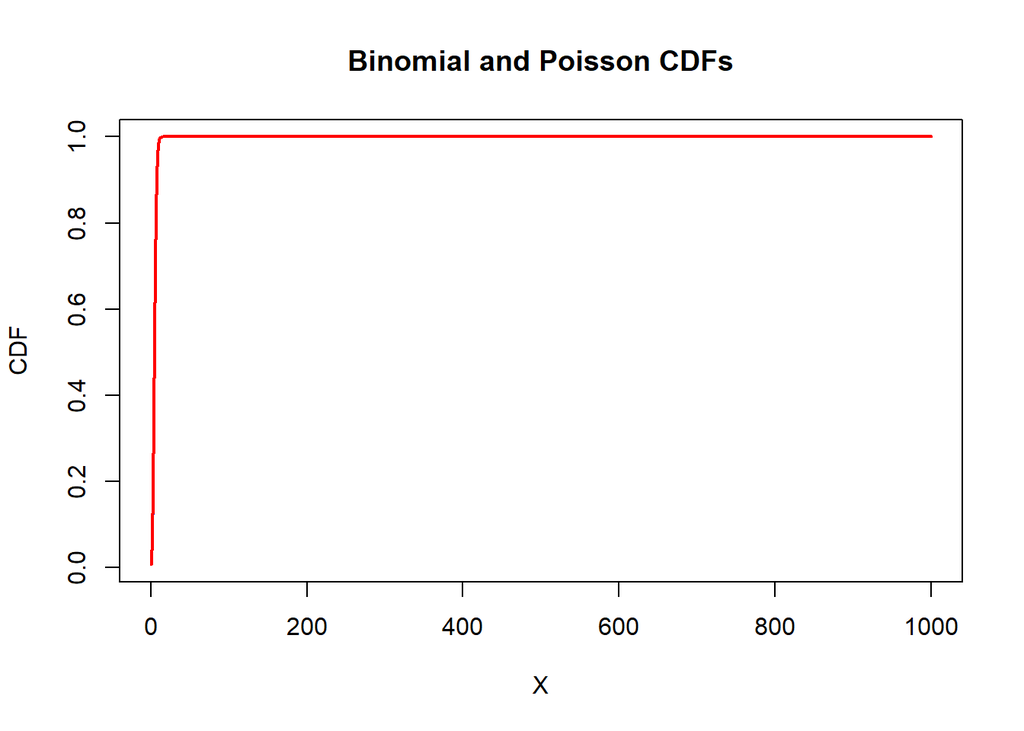

```r
n_binom <- 1000
p_binom <- 0.005
mu_pois <- 5

# Create a vector of x values
x <- 0:max(n_binom, mu_pois * 3)

# Calculate CDFs for both distributions
binom_cdf <- pbinom(x, size = n_binom, prob = p_binom)
poisson_cdf <- ppois(x, lambda = mu_pois)

# Create a plot
plot(x, binom_cdf, type = "l", col = "blue", lwd = 2,
     xlab = "X", ylab = "CDF", main = "Binomial and Poisson CDFs")

# Add the Poisson CDF to the existing plot
lines(x, poisson_cdf, type = "l", col = "red", lwd = 2)
```

Do the graphs overlap? Why/Why not? YOUR ANSWER: - We can’t see the Binomial distribution graph, meaning that they do have to overlap in order for the poisson to just be presented by itself

# 4 Normal Distibution

In this section we will explore the normal distribution.

## 4.1 Fixed mean, varying standard deviation

### 4.1.1 Plotting Densities

Set $\mu = 5$. For values of $\sigma$ given by $0.2, 0.4, 0.8, 1, 1.3, 1.8, 2$, plot the densities of $N(\mu, \sigma)$ in the same plot. It might help if (1) you have the densities of $N(\mu = 5, \sigma = 0.2)$ and $N(\mu = 5, \sigma = 2)$ to be blue in color and the rest to be red. (2) choose appropriate limits for the x-axis (use x_lim parameter in the plot funtion) and y-axis (use y_lim).

Method 1: Using ‘plot’ function from R-base

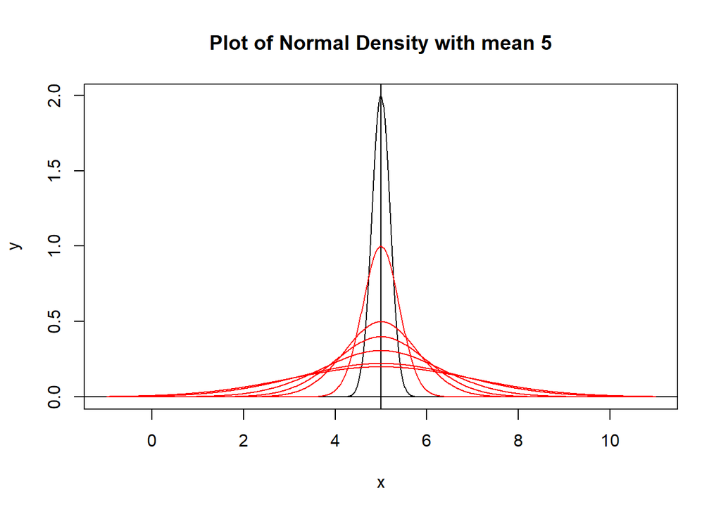

```r
mu <- 5
sds <- c(0.4, 0.8, 1, 1.3, 1.8, 2)

x <- seq(-6, 6, length.out = 1000)
x <- 5+x
y <- dnorm(x, mean = 5, sd=0.2)

plot(x, y,
     type = 'l',
     main= "Plot of Normal Density with mean 5")
abline(v=5, h=0)
for(std in sds){
  y_temp <- dnorm(x, mean = 5, sd=std)
  lines(x, y_temp,
        type = 'l',
        col = 'red')
}
```

Method 2: Using ggplot

```r
library(tidyverse)
x <- seq(-6, 6, length.out = 1000)
x <- 5+x
```

```r
y_0.2 <- dnorm(x, mean= 5, sd = 0.2)
y_0.4 <- dnorm(x, mean= 5, sd = 0.4)
y_0.8 <- dnorm(x, mean= 5, sd = 0.8)
y_1 <- dnorm(x, mean= 5, sd = 1)
y_1.3 <- dnorm(x, mean= 5, sd = 1.3)
y_1.8 <- dnorm(x, mean = 5, sd = 1.8)
y_2 <- dnorm(x, mean= 5, sd = 2)

plot_data_pdf <- data.frame(x,y_0.2,y_0.4,y_0.8,y_1,y_1.3, y_1.8, y_2)
```

```r
plot_data_pdf_new <- pivot_longer(plot_data_pdf,
                                  cols = c(y_0.2,y_0.4,y_0.8,y_1,y_1.3, y_1.8, y_2),
                                  names_to = "std_devs"
                                  )
```

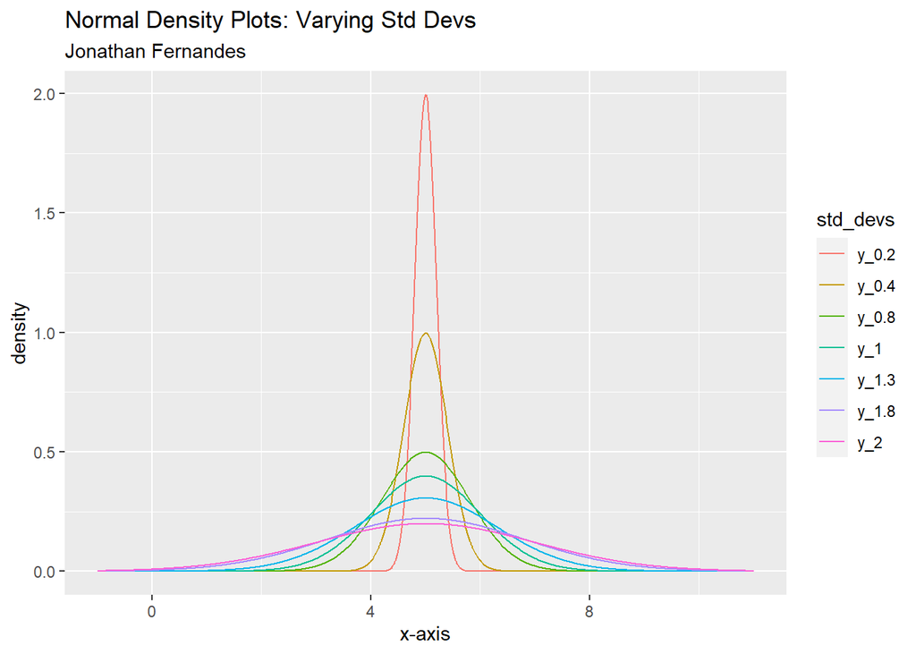

```r
ggplot(data = plot_data_pdf_new,
  aes(x = x,
      y = value,
      group = std_devs,
      color = std_devs))+
  geom_line()+
  labs(title = "Normal Density Plots: Varying Std Devs",
       subtitle = "Jonathan Fernandes",
       x = "x-axis",
       y = "density")
```

What do you notice about the plot? Comment about how the width changes. - The width gets tighter when our standard deviation gets smaller. The opposite happens when our standard deviation gets bigger.

### 4.1.2 Plotting Cummulative Distribution Functions

Set $\mu = 5$. For values of $\sigma$ given by $0.2, 0.4, 0.8, 1, 1.3, 1.8, 2$, plot the cummulative distribution function of $N(\mu, \sigma)$ in the same plot. It might help if (1) you have the cdf of $N(\mu = 5, \sigma = 0.2)$ and $N(\mu = 5, \sigma = 2)$ to be blue in color and the rest to be red. (2) choose appropriate limits for the x-axis (use x_lim parameter in the plot funtion) and y-axis (use y_lim).

```r
z_0.2 <- pnorm(x, mean= 5, sd = 0.2)
z_0.4 <- pnorm(x, mean= 5, sd = 0.4)
z_0.8 <- pnorm(x, mean= 5, sd = 0.8)
z_1 <- pnorm(x, mean= 5, sd = 1)
z_1.3 <- pnorm(x, mean= 5, sd = 1.3)
z_1.8 <- pnorm(x, mean = 5, sd = 1.8)
z_2 <- pnorm(x, mean= 5, sd = 2)

plot_data_cdf <- data.frame(x,z_0.2,z_0.4,z_0.8,z_1,z_1.3, z_1.8, z_2)
```

```r
plot_data_cdf_new <- pivot_longer(plot_data_cdf,
                                  cols = c(z_0.2,z_0.4,z_0.8,z_1,z_1.3, z_1.8, z_2),
                                  names_to = "std_devs"
                                  )
```

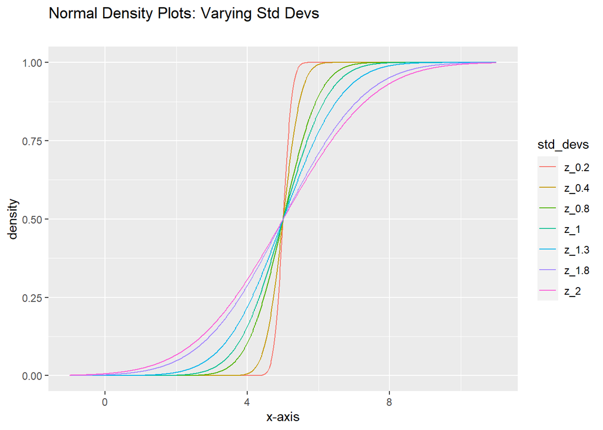

```r
ggplot(data = plot_data_cdf_new,
  aes(x = x,
      y = value,
      group = std_devs,
      color = std_devs))+
  geom_line()+
  labs(title = "Normal Density Plots: Varying Std Devs",
       subtitle = "",
       x = "x-axis",
       y = "density")
```

What information does the point of intersection of two cdfs give us? - That the probability of the two random variables being <= to a certain value are both the same

## 4.2 Varying mean, fixed standard deviation

```r
m_1 <- pnorm(x, mean= -1, sd = 0.4)
m_0.5 <- pnorm(x, mean= -0.5, sd = 0.4)
m_0 <- pnorm(x, mean= 0, sd = 0.4)
m_0.4 <- pnorm(x, mean= 0.4, sd = 0.4)
m_0.9 <- pnorm(x, mean= 0.9, sd = 0.4)
m_2.5 <- pnorm(x, mean= 2.5, sd = 0.4)
m_4 <- pnorm(x, mean= 4, sd = 0.4)

plot_data_cdf <- data.frame(x,m_1,m_0.5,m_0,m_0.4,m_0.9, m_2.5, m_4)
```

```r
plot_data_cdf_new <- pivot_longer(plot_data_cdf,
                                  cols = c(m_1,m_0.5,m_0,m_0.4,m_0.9, m_2.5, m_4),
                                  names_to = "means"
                                  )
```

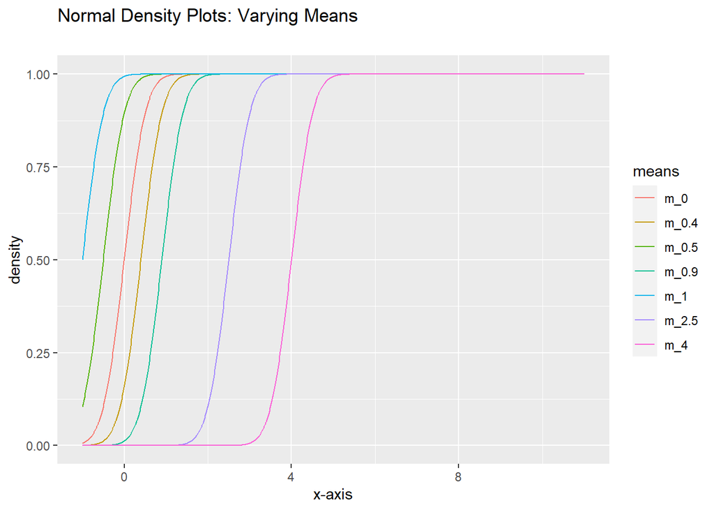

```r
ggplot(data = plot_data_cdf_new,
  aes(x = x,
      y = value,
      group = means,
      color = means))+
  geom_line()+
  labs(title = "Normal Density Plots: Varying Means",
       subtitle = "",
       x = "x-axis",
       y = "density")
```

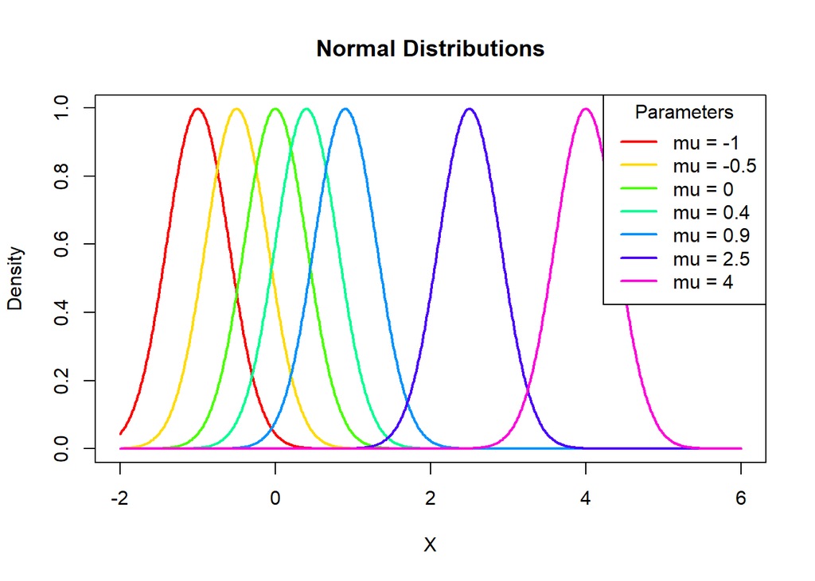

```r
mu_values <- c(-1, -0.5, 0, 0.4, 0.9, 2.5, 4)

# Define the common standard deviation
sigma <- 0.4

# Create a vector of x values with appropriate limits
x <- seq(-2, 6, by = 0.01)  # Adjust the range as needed

# Initialize an empty plot
plot(x, dnorm(x, mean = mu_values[1], sd = sigma), type = "l", col = "blue", lwd = 2,
     xlab = "X", ylab = "Density", main = "Normal Distributions")

# Loop through the mu values and plot the densities
colors <- rainbow(length(mu_values))
for (i in 1:length(mu_values)) {
  mu <- mu_values[i]
  density <- dnorm(x, mean = mu, sd = sigma)
  lines(x, density, col = colors[i], lwd = 2)
}

# Add a legend
legend("topright", legend = paste("mu =", mu_values), col = colors, lwd = 2, title = "Parameters")
```

# 5 Exponential Distribution

## 5.1 Probablity Density Function

For values of $\lambda$ in $(0.2, 0.5, 1, 2, 8, 10)$ plot the graphs of the densities of $\text{Exp}(\lambda)$ in the same plot.

```r
n_0.2 <- dexp(x, rate = 0.2)
n_0.5 <- dexp(x, rate = 0.5)
n_1 <- dexp(x, rate = 1)
n_2 <- dexp(x, rate = 2)
n_8 <- dexp(x, rate = 8)
n_10 <- dexp(x, rate = 10)

plot_data_pdf <- data.frame(x,n_0.2, n_0.5, n_1, n_2, n_8, n_10)
```

```r
plot_data_pdf_new <- pivot_longer(plot_data_pdf,
                                  cols = c(n_0.2, n_0.5, n_1, n_2, n_8, n_10),
                                  names_to = "rates"
                                  )
```

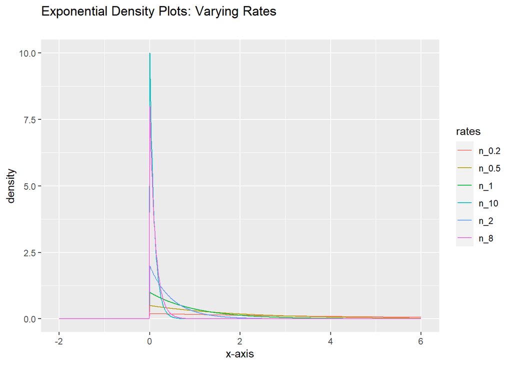

```r
ggplot(data = plot_data_pdf_new,
  aes(x = x,
      y = value,
      group = rates,
      color = rates))+
  geom_line()+
  labs(title = "Exponential Density Plots: Varying Rates",
       subtitle = "",
       x = "x-axis",
       y = "density")
```

## 5.2 Cummulative Distribution Function

For values of $\lambda$ in $(0.2, 0.5, 1, 2, 8, 10)$ plot the graphs of the cumulative distribution function of $\text{Exp}(\lambda)$ in the same plot. Draw a horizontal line at $y=0.8$.

```r
n_0.2 <- pexp(x, rate = 0.2)
n_0.5 <- pexp(x, rate = 0.5)
n_1 <- pexp(x, rate = 1)
n_2 <- pexp(x, rate = 2)
n_8 <- pexp(x, rate = 8)
n_10 <- pexp(x, rate = 10)

plot_data_cdf <- data.frame(x,n_0.2, n_0.5, n_1, n_2, n_8, n_10)
```

```r
plot_data_cdf_new <- pivot_longer(plot_data_cdf,
                                  cols = c(n_0.2, n_0.5, n_1, n_2, n_8, n_10),
                                  names_to = "rates"
                                  )
```

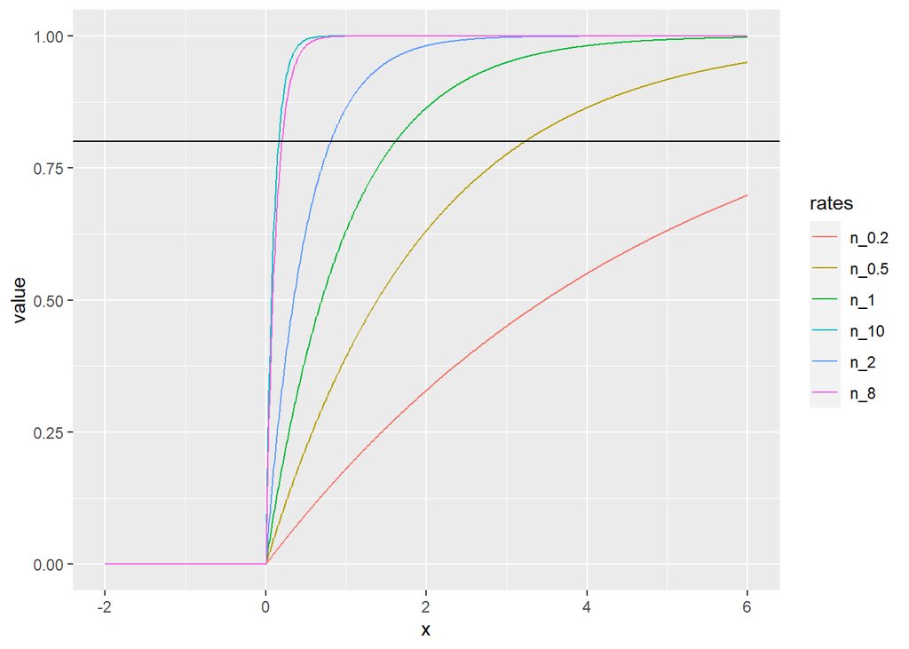

```r
ggplot(data = plot_data_cdf_new,
  aes(x = x,
      y = value,
      group = rates,
      color = rates))+
  geom_line()+
  geom_hline(yintercept = 0.8)
```

```r
  labs(title = "Exponential Cummalative Plots: Varying Rates",
       subtitle = "",
       x = "x-axis",
       y = "density")
```

```
## $x
## [1] "x-axis"
##
## $y
## [1] "density"
##
## $title
## [1] "Exponential Cummalative Plots: Varying Rates"
##
## $subtitle
## [1] ""
##
## attr(,"class")
## [1] "labels"
```

Interpret the values of $x$ where the line $y=0.8$ intersects with the graphs of the cdfs. YOUR ANSWER: - when the x-values intersect y = 0.8 it means that the probability of x has reached 0.8 with the given random variable.

# 6 Gamma Distibution

We will plot the Gamma distribution for different shapes and scales. You might need to adjust the limits of x and y axes appropriately.

## 6.1 Different Shapes

For values of $\alpha \in (0.3,0.7, 1, 1.5, 2, 2.5, 10)$, plot the Plot the densities of $\text{Gamma}(\alpha, \beta = 1)$ in a single plot.

```r
x <- seq(0, 10, length.out = 1000)
```

```r
y_0.3 <- dgamma(x, shape = 0.3, scale = 1)
y_0.7 <- dgamma(x, shape = 0.7, scale = 1)
y_1 <- dgamma(x, shape = 1, scale = 1)
y_1.5 <- dgamma(x, shape = 1.5, scale = 1)
y_2 <- dgamma(x, shape = 2, scale = 1)
y_2.5 <- dgamma(x, shape = 2.5, scale = 1)
y_10 <- dgamma(x, shape = 10, scale = 1)

plot_data_pdf <- data.frame(x,y_1,y_1.5,y_2, y_2.5,y_10)
```

```r
plot_data_pdf_new <- pivot_longer(plot_data_pdf,
                                  cols = c(y_1,y_1.5,y_2, y_2.5,y_10),
                                  names_to = "shapes"
                                  )
```

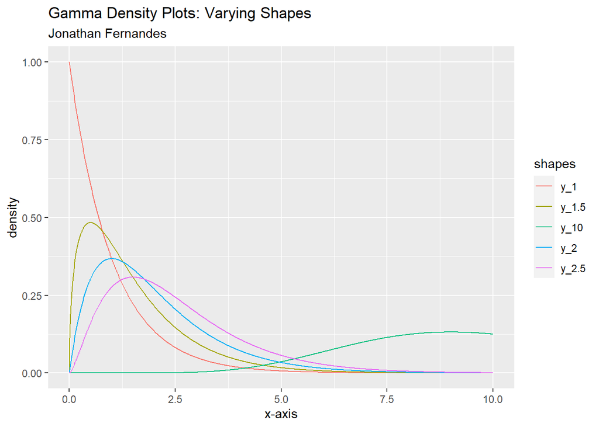

```r
ggplot(data = plot_data_pdf_new,
  aes(x = x,
      y = value,
      group = shapes,
      color = shapes))+
  geom_line()+
  labs(title = "Gamma Density Plots: Varying Shapes",
       subtitle = "Jonathan Fernandes",
       x = "x-axis",
       y = "density")
```

## 6.2 $\alpha =1$ , varying scales

Set $\alpha = 1$, vary $\beta$ over $0.2, 0.6, 1, 1.5, 2$. Plot the densities of $\text{Gamma}(\alpha, \beta)$ in a single plot.

```r
x <- seq(0, 10, length.out = 1000)
```

```r
y_0.2 <- dgamma(x, shape = 1, scale = 0.2)
y_0.6 <- dgamma(x, shape = 1, scale = 0.6)
y_1 <- dgamma(x, shape = 1, scale = 1)
y_1.5 <- dgamma(x, shape = 1, scale = 1.5)
y_2 <- dgamma(x, shape = 1, scale = 2)

plot_data_pdf <- data.frame(x,y_0.2,y_0.6,y_1,y_1.5, y_2)
```

```r
plot_data_pdf_new <- pivot_longer(plot_data_pdf,
                                  cols = c(y_0.2,y_0.6,y_1,y_1.5, y_2),
                                  names_to = "scales"
                                  )
```

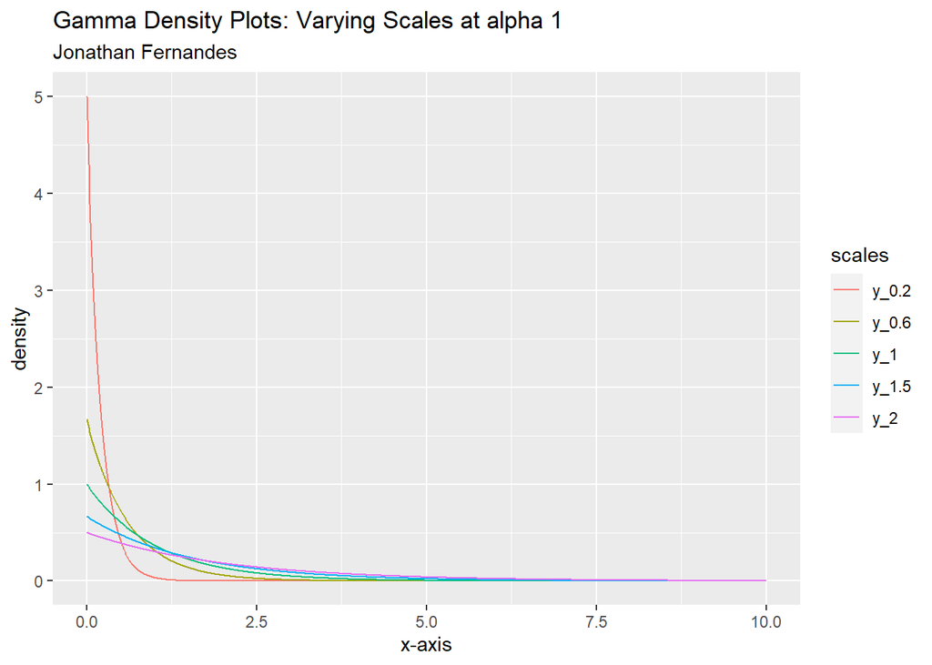

```r
ggplot(data = plot_data_pdf_new,
  aes(x = x,
      y = value,
      group = scales,
      color = scales))+
  geom_line()+
  labs(title = "Gamma Density Plots: Varying Scales at alpha 1",
       subtitle = "Jonathan Fernandes",
       x = "x-axis",
       y = "density")
```

## $\alpha =0.6$ , varying scales Set $\alpha = 0.6$, vary $\beta$ over $0.2, 0.6, 1, 1.5, 2$. Plot the densities of $\text{Gamma}(\alpha, \beta)$ in a single plot.

```r
x <- seq(0, 10, length.out = 1000)
```

```r
y_0.2 <- dgamma(x, shape = 0.6, scale = 0.2)
y_0.6 <- dgamma(x, shape = 0.6, scale = 0.6)
y_1 <- dgamma(x, shape = 0.6, scale = 1)
y_1.5 <- dgamma(x, shape = 0.6, scale = 1.5)
y_2 <- dgamma(x, shape = 0.6, scale = 2)

plot_data_pdf <- data.frame(x,y_0.2,y_0.6,y_1,y_1.5, y_2)
```

```r
plot_data_pdf_new <- pivot_longer(plot_data_pdf,
                                  cols = c(y_0.2,y_0.6,y_1,y_1.5, y_2),
                                  names_to = "scales"
                                  )
```

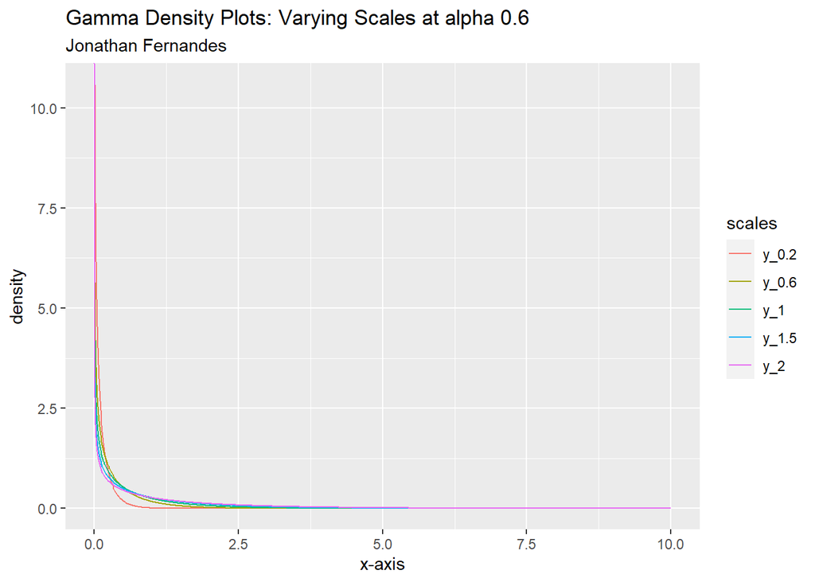

```r
ggplot(data = plot_data_pdf_new,
  aes(x = x,
      y = value,
      group = scales,
      color = scales))+
  geom_line()+
  labs(title = "Gamma Density Plots: Varying Scales at alpha 0.6",
       subtitle = "Jonathan Fernandes",
       x = "x-axis",
       y = "density")
```

## 6.3 $\alpha = 2$ , varying scales

Set $\alpha = 2$, vary $\beta$ over $0.2, 0.6, 1, 1.5, 2$. Plot the densities of $\text{Gamma}(\alpha, \beta)$ in a single plot.

```r
x <- seq(0, 10, length.out = 1000)
```

```r
y_0.2 <- dgamma(x, shape = 2, scale = 0.2)
y_0.6 <- dgamma(x, shape = 2, scale = 0.6)
y_1 <- dgamma(x, shape = 2, scale = 1)
y_1.5 <- dgamma(x, shape = 2, scale = 1.5)
y_2 <- dgamma(x, shape = 2, scale = 2)

plot_data_pdf <- data.frame(x,y_0.2,y_0.6,y_1,y_1.5, y_2)
```

```r
plot_data_pdf_new <- pivot_longer(plot_data_pdf,
                                  cols = c(y_0.2,y_0.6,y_1,y_1.5, y_2),
                                  names_to = "scales"
                                  )
```

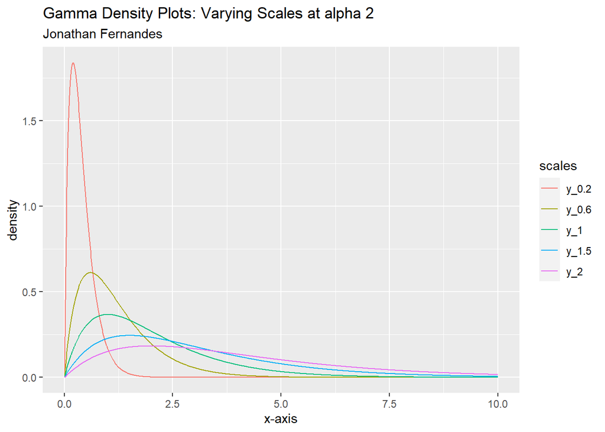

```r
ggplot(data = plot_data_pdf_new,
  aes(x = x,
      y = value,
      group = scales,
      color = scales))+
  geom_line()+
  labs(title = "Gamma Density Plots: Varying Scales at alpha 2",
       subtitle = "Jonathan Fernandes",
       x = "x-axis",
       y = "density")
```

## 6.4 $\alpha = 5$ , varying scales

Set $\alpha = 5$, vary $\beta$ over $0.2, 0.6, 1, 1.5, 2$. Plot the densities of $\text{Gamma}(\alpha, \beta)$ in a single plot.

```r
x <- seq(0, 10, length.out = 1000)
```

```r
y_0.2 <- dgamma(x, shape = 5, scale = 0.2)
y_0.6 <- dgamma(x, shape = 5, scale = 0.6)
y_1 <- dgamma(x, shape = 5, scale = 1)
y_1.5 <- dgamma(x, shape = 5, scale = 1.5)
y_2 <- dgamma(x, shape = 5, scale = 2)

plot_data_pdf <- data.frame(x,y_0.2,y_0.6,y_1,y_1.5, y_2)
```

```r
plot_data_pdf_new <- pivot_longer(plot_data_pdf,
                                  cols = c(y_0.2,y_0.6,y_1,y_1.5, y_2),
                                  names_to = "scales"
                                  )
```

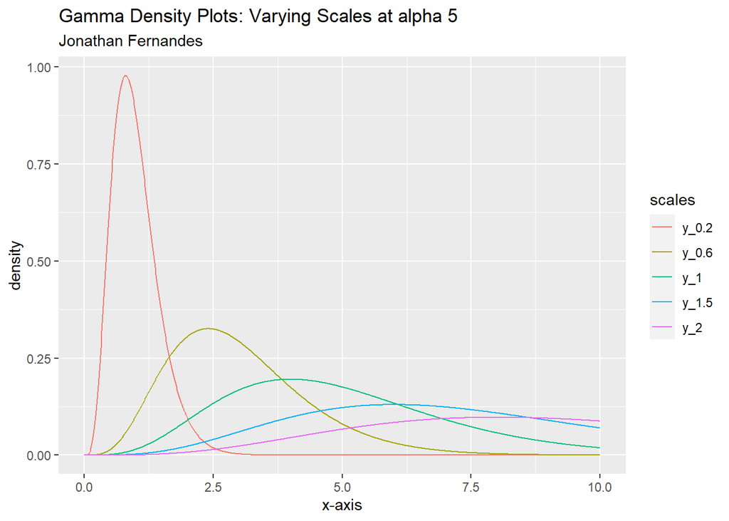

```r
ggplot(data = plot_data_pdf_new,
  aes(x = x,
      y = value,
      group = scales,
      color = scales))+
  geom_line()+
  labs(title = "Gamma Density Plots: Varying Scales at alpha 5",
       subtitle = "Jonathan Fernandes",
       x = "x-axis",
       y = "density")
```